# Bayesian Inference for SIR Epidemic Models using odin and monty

Author: Julia Mayer

Last modified: 15.12.2025

# 1 Introduction

This notebook exemplifies the use of Bayesian statistics for **SIR (Susceptible-Infected-Recovered) epidemic models** using the **odin, dust, and monty** packages. The packages, unlike BayesianTools, provides a “domain specific language” (DSL) which looks like R but is compiled directly to C++. This makes them very fast while not requiring the knowledge of other languages such as Stan or C++. **odin2** is used to define the SIR model by specifying the ordinary differential equations that govern it. **dust** compiles the model to a particle filter-compatible format, and **monty** performs the MCMC fitting.

We’ll cover:

- odin2: https://mrc-ide.github.io/odin2/
- dust2: https://mrc-ide.github.io/dust2/
- monty: https://mrc-ide.github.io/monty/

This notebook is heavily inspired by the **monty** and **bayesintro** vignettes.

## 1.1 Why odin and mcstate?

**Advantages:**

- R interface - no experience with Stan, C++ or C needed
- Multiple MCMC algorithms available
- Faster than BayesianTools

**Trade-offs:**

- Steep learning curve
- Very new packages so limited flexibility
- Not all functions are supported in odin models, sometimes making debugging difficult
- Limited community support compared to more established packages like Bayesiantool
- No built-in diagnostic tools

## 1.2 The SIR Model (Quick Review)

The SIR model divides a population into three compartments:

$$\begin{aligned}
\frac{dS}{dt} &= -\beta \frac{SI}{N} \\
\frac{dI}{dt} &= \beta \frac{SI}{N} - \gamma I \\
\frac{dR}{dt} &= \gamma I
\end{aligned}$$

Where:

- $S$: Number of susceptible individuals
- $I$: Number of infected individuals
- $R$: Number of recovered individuals
- $N$: Total population size ($N = S + I + R$)
- $\beta$: Transmission rate
- $\gamma$: Recovery rate
- $\frac{1}{\gamma}$: Average infectious period
- $R_0 = \frac{\beta}{\gamma}$: Basic reproduction number
- $I_0$: Initial number of infected individuals

# 2 Housekeeping (load required libraries and set seed for reproducibility)

```r
set.seed(42)

if (!require("pacman")) install.packages("pacman")
```

```r
pacman::p_load(odin2, dust2, monty, dplyr, tidyr, ggplot2, kableExtra, knitr,
               bayesplot, posterior)
```

# 3 Step 1: Simulate SIR Epidemic Data

```r
# Load model
# change the path to where your model is saved
model_path <- "/Users/juliamayer/Library/CloudStorage/OneDrive-Charité-UniversitätsmedizinBerlin/Training/To share/Model building and fitting with monty/"
# model_file <- paste0(model_path, "deterministic SIR odin.R")
model_file <- paste0(model_path, "stochastic SIR odin.R")

gen_sir <- odin(model_file)
```

[output not shown]

# 4 Step 1: simple model run

This can be helpful to check that your model is behaving as expect (e.g., no negative numbers for people). We will also use to generate data to fit the model to later. We set the true values of the parameters we will later try to estimate. We set the initial number of infected individuals to 1, the transmission rate $\beta$ to 0.1 and the average infectious period to 20 days ($\gamma$ = 0.05). With these values, we have $R_0 = \frac{\beta}{\gamma} =$ 2.

Here, we are generating incidence data,

```r
# You can parse parameter values and initial states that are different from the ones specified in your odin model
true_pars <- list(beta = 0.1,
             gamma = 0.05,
             I0 = 1
)

# You can try different parameter values here
# pars <- list(beta = 0.1,
#              gamma = 0.03,
#              I0 = 2
# )

# View parameters
kable(as.data.frame(true_pars), caption = "True parameter values", align = "cc") |>
  column_spec(1:3, width = "13mm")
```

True parameter values

| beta | gamma | I0 |
| --- | --- | --- |
| 0.1 | 0.05 | 1 |

We need to create a dust system from our *odin* model in order to simulate it. You can choose how many steps per day you want to take with the *dt* argument and how many runs you want to simulate with *n_particles*. All systems start with a zero state unless you set them via *dust_system_set_state()* or *dust_system_set_state_initial()*.

```r
# We use 1 particle here as we are just running one simulation.
# With dt = 0.25, we take 4 steps per day. This can be changed to 0.5 or 1.
sys <- dust_system_create(gen_sir(), true_pars, n_particles = 1, dt = 0.25)
dust_system_set_state_initial(sys)

# This will run one iteration of the model forward over 500 days.
time <- 0:500
y <- dust_system_simulate(sys, time)
```

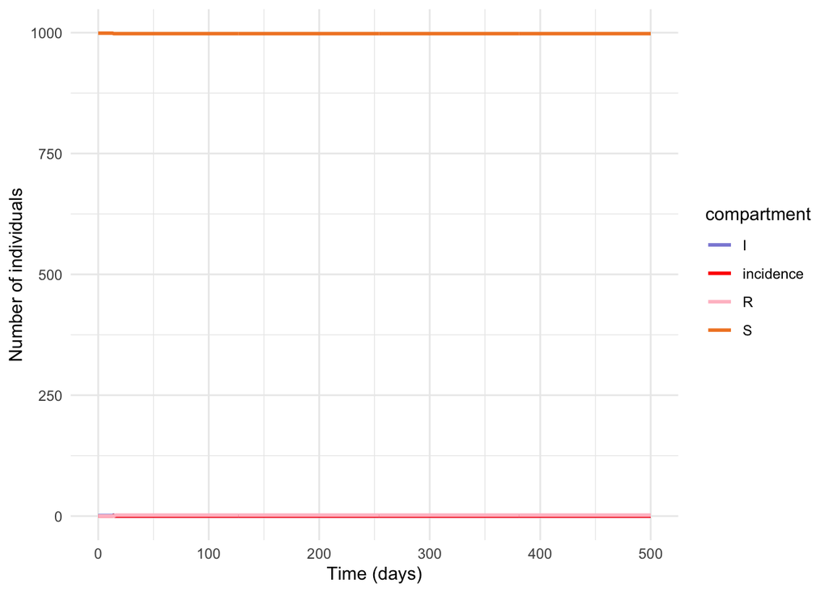

```r
# Visualise how the population changes over time
# Define a palette
palette <- c("S" = "#F2862C",  "I" = "#8c8cd9", "R" = "pink", incidence = "red")

# Extract the values of the different compartments over time
S <- dust_unpack_state(sys, y)$S
I <- dust_unpack_state(sys, y)$I
R <- dust_unpack_state(sys, y)$R
cases <- dust_unpack_state(sys, y)$incidence

# Combine them in a dataframe for easier plotting
states <- data.frame(time = time,
                     S = S,
                     I = I,
                     R = R,
                     incidence = cases)

# Plot
states %>%
  pivot_longer(cols = -time, names_to = "compartment", values_to = "individuals") %>%
  ggplot(aes(x = time, y = individuals, color = compartment)) +
  geom_line(linewidth = 1) +
  scale_color_manual(values = palette) +
  labs(x = "Time (days)", y = "Number of individuals") +
  theme_minimal()
```

If you’re using the stochastic model, each run will results in a different trajectory. Therefore, you might need to run it several times to see a clear epidemic curve. We will extract the proportion of cases at specific time points to generate incidence data.

```r
# Extract the number of cases at specific time points
time_points <- c(30, 60, 90, 120, 150, 180, 240, 300, 360, 420, 480)
incidence <- data.frame(time = time_points,
                         cases = round(cases[time_points + 1])) # +1 because time starts at 0

# View the incidence data
kable(incidence, col.names = c("Time (days)", "Incidence"),
             caption = "Simulated incidence data", align = "cc") |>
  column_spec(1:2, width = "40mm")
```

Simulated incidence data

| Time (days) | Incidence |
| --- | --- |
| 30 | 0 |
| 60 | 0 |
| 90 | 0 |
| 120 | 0 |
| 150 | 0 |
| 180 | 0 |
| 240 | 0 |
| 300 | 0 |
| 360 | 0 |
| 420 | 0 |
| 480 | 0 |

# 5 Step 2: Fitting

If the model is behaving as expected, you can move on to the fitting. We will fit the model to the generated incidence data using the *monty* package.

To fit the model, we need a function that tells us if the model output is close to the observed data. This is the comparison function that is used by the particle filter and that computes the log-likelihood. When using *odin2* and *monty*, this is done in the model (see the last three lines of the model code). We can now build a particle filter that will use this function and test the outputs of it.

```r
# Build a filter and test it using the true parameter values
filter <- dust_filter_create(gen_sir,
                             time_start = 0,
                             data = incidence,
                             n_particles = 1000) # now we run the filter 1,000 times

dust_likelihood_run(filter,
                    pars = true_pars,
                    save_trajectories = T) # we are saving the trajectories for plotting
```

```
## [1] -0.7941689
```

```r
# You can try different values for the parameters here to see how the likelihood changes
# dust_likelihood_run(filter,
#                     pars = list(beta = 0.1,
#                                 gamma = 0.03,
#                                 I0 = 45)
#                     )
```

When using real data it can be helpful to plot the model and the data together to see why the filter is returning a specific likelihood value, especially if it’s not what you would expect (e.g., it’s very low).

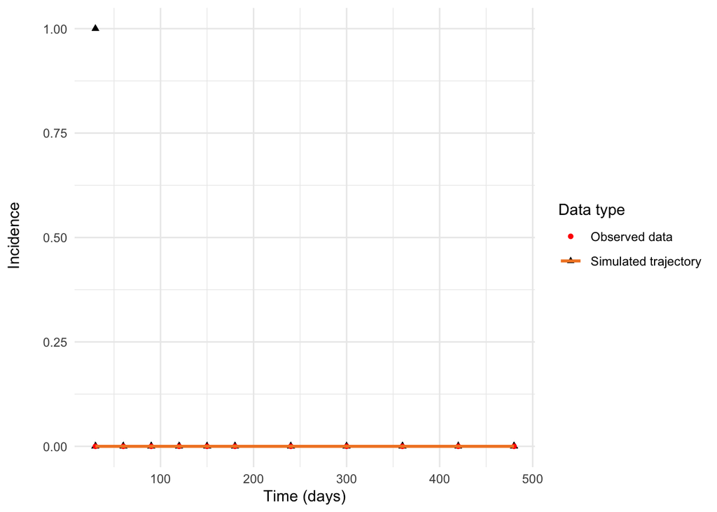

```r
# Plot the fit
# You can try doing this for different parameter values to see how the model fits the data
h <- dust_likelihood_last_trajectories(filter)

# We extract the values of the 1,000 runs
traj <- data.frame((dust_unpack_state(filter, h)$incidence)) %>%
  mutate(run_id = row_number()) %>%
  pivot_longer(cols = -run_id, names_to = "time", values_to = "cases") %>%
  mutate(time = as.integer(gsub("X", "", time)),
         cases = round(cases)) %>%
  merge(data.frame(time_points) %>%
          mutate(time = row_number()), by = "time") %>%
  arrange(run_id, time)

# We take the median of the simulated trajectories since we're simulated 1,000 runs
traj_med <- traj %>%
  group_by(time_points) %>%
  summarise(cases = median(cases))

traj %>% ggplot() +
  geom_point(aes(x = time_points, y = cases, shape = "Simulated trajectory")) +
  geom_point(data = incidence,
             aes(x = time, y = cases, shape = "Observed data", col = "Observed data")) +
  geom_line(data = traj_med,
            aes(x = time_points, y = cases, col = "Simulated trajectory"),
            linewidth = 1) +
  scale_color_manual(values = c("Simulated trajectory" = "#F2862C", "Observed data" = "red")) +
  labs(x = "Time (days)",
       y = " Incidence\n",
       shape = "Data type",
       colour = "Data type") +
  theme_minimal()
```

If you’re using the stochastic model, each trajectory is different but the median values (orange line) capture the shape of the observed data. If you’re using a deterministic model, all trajectories will be the same and the simulated data should be equal to the observed data.